# Probability and Statistics

# Lab Assignment 1: Naive Bayes Classifier

## Work breakdown

- *Pavlo Ruzhylo*: Data preprocessing, model fitting, measurements of effectiveness of a model.
- *Ivan Polianskyy*: Data visualization
- *Maksym Matseliukh*: Conclusions

## Introduction

During the first three weeks, you learned a couple of essential notions and theorems, and one of the most important among them is the **Bayes theorem**.

**Naive Bayes Classifier** is a simple algorithm, which is based on **Bayes theorem** and used for solving classification problems. **Classification problem** is a problem in which an observation has to be classified in one of the $n$ classes based on its similarity with observations in each class.

It is a **probabilistic classifier**, which means it predicts based on the probability of an observation belonging to each class. To compute it, this algorithm uses **Bayes’ formula,** that you probably already came across in **Lesson 3:**
$$\mathsf{P}(\mathrm{class}\mid
\mathrm{observation})=\frac{\mathsf{P}(\mathrm{observation}\mid\mathrm{class})\mathsf{P}(\mathrm{class})}{\mathsf{P}(\mathrm{observation})}$$

Under the strong **independence** assumption, one can calculate $\mathsf{P}(\mathrm{observation} \mid \mathrm{class})$ as
$$\mathsf{P}(\mathrm{observation}) =
\prod_{i=1}^{n} \mathsf{P}(\mathrm{feature}_i), \qquad
\mathsf{P}(\mathrm{observation} \mid \mathrm{class}) = \prod_{i=1}^{n}
\mathsf{P}(\mathrm{feature}_i \mid \mathrm{class}),$$
where $n$ is the total number of features describing a given observation (*For example, if an observation is presented as a sentence, then each word can be a feature*). Thus, $\mathsf{P}(\mathrm{class}|\mathrm{observation})$ now can be calculated as

$$\mathsf{P}(\mathrm{class} \mid
\mathrm{\mathrm{observation}}) = \mathsf{P}(\mathrm{class})\times
\prod_{i=1}^{n}\frac{\mathsf{P}(\mathrm{feature}_i\mid
\mathrm{class})}{\mathsf{P}(\mathrm{feature}_i)}\tag{1}$$

All the terms on the right-hand side can be estimated as corresponding relative frequencies using available data

**See [*this link*](https://www.javatpoint.com/machine-learning-naive-bayes-classifier) for more detailed explanations & examples :) Also you can watch [*this video*](https://youtu.be/O2L2Uv9pdDA?si=-ohkHVDuu3sLLGMq) for more examples!**

## Data description

There are 5 datasets uploaded on the cms (data.zip)

Our dataset: - **0 - authors** This data set consists of citations of three famous writers: Edgar Alan Poe, Mary Wollstonecraft Shelley and HP Lovecraft. The task with this data set is to classify a piece of text with the author who was more likely to write it.

Each data set consists of two files: *train.csv* and *test.csv*. The first one is used to find the probabilities of the corresponding classes and the second one is used to test your classifier afterwards. Note that it is crucial to randomly split your data into training and testing parts to test the classifierʼs possibilities on the unseen data.

```r
library(tidytext)
library(readr)
library(dplyr)
```

```r
library(ggplot2)
library(tidyr)
library(wordcloud)
library(RColorBrewer)
```

## Outline of the work

1. **Data pre-processing** (includes removing punctuation marks and stop words, representing each message as a bag-of-words)
2. **Data visualization** (it’s time to plot your data!)
3. **Classifier implementation** (using the training set, calculate all the conditional probabilities in formula (1))
4. **Measurements of effectiveness of your classifier** (use the results from the previous step to predict classes for messages in the testing set and measure the accuracy, precision and recall, F1 score metric etc)
5. **Conclusions**

*!! do not forget to submit both the (compiled) Rmd source file and the .html output !!*

## Data pre-processing

- Read the *.csv* data files.
- Сlear your data from punctuation or other unneeded symbols.
- Clear you data from stop words. You don’t want words as is, and, or etc. to affect your probabilities distributions, so it is a wise decision to get rid of them. Find list of stop words in the cms under the lab task.
- Represent each test message as its bag-of-words. Here: https://machinelearningmastery.com/gentle-introduction-bag-words-model/ you can find general introduction to the bag-of-words model and examples on to create it.

```r
test_path <- "data/0-authors/test.csv"
train_path <- "data/0-authors/train.csv"

stop_words <- read_file("stop_words.txt")
# https://stackoverflow.com/questions/27195912/why-does-strsplit-return-a-list
splitted_stop_words <- strsplit(stop_words, split='\n')
splitted_stop_words <- splitted_stop_words[[1]]
# splitted_stop_words
# head(splitted_stop_words)
```

```r
train <-  read.csv(file = train_path, stringsAsFactors = FALSE)
test <-  read.csv(file = test_path, stringsAsFactors = FALSE, quote="\"")
```

```r
# note the power functional features of R bring us!
tidy_text <- unnest_tokens(train[, ], "splitted", 'text', token="words") %>%
    filter(!splitted %in% splitted_stop_words)

X_test <- test$text
y_test <- test$author
```

```r
#Converting each message into bag of words:
vocabulary <- unique(tidy_text$splitted)
authors <- unique(tidy_text$author)

bow <- tidy_text %>% count(id, splitted)
author_labels <- tidy_text %>%
  select(id, author) %>%
  distinct()
bow <- bow %>%
  pivot_wider(
    names_from = splitted,
    values_from = n,
    values_fill = list(n = 0),
    names_repair="unique"
  )
```

## Data visualization

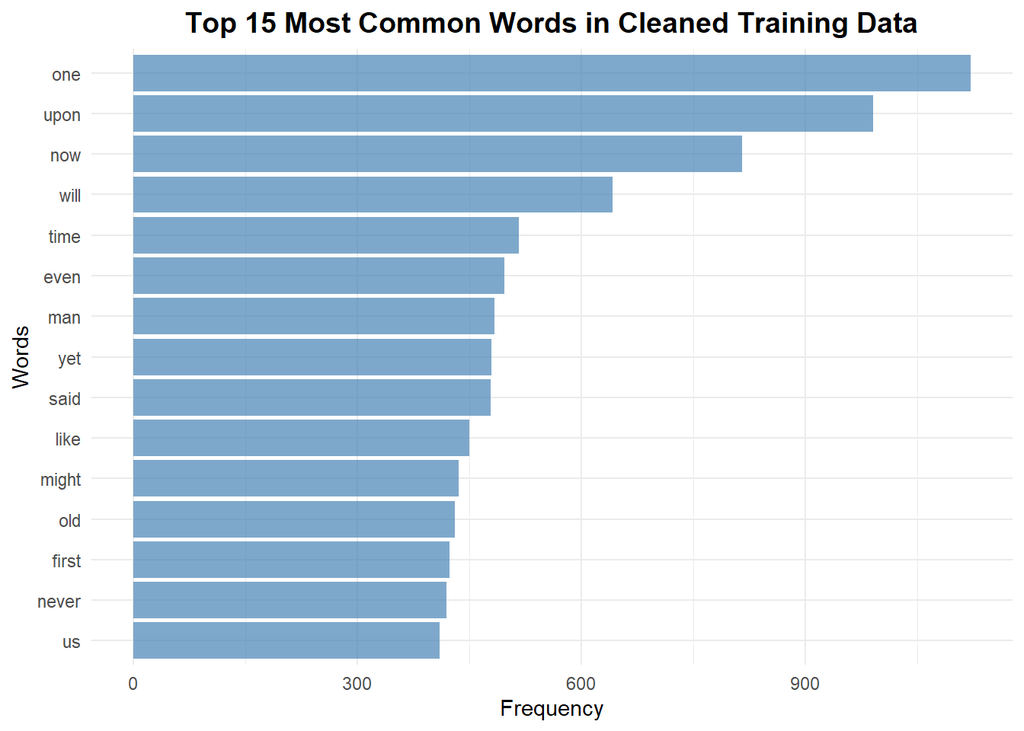

```r
word_freq <- tidy_text %>%
  group_by(author, splitted) %>%
  summarise(freq = n(), .groups = "drop") %>%
  arrange(author, desc(freq))


overall_word_freq <- tidy_text %>%
  count(splitted, sort = TRUE) %>%
  head(15) #<<<<<-------???????????


ggplot(overall_word_freq, aes(x = reorder(splitted, n), y = n)) +
  geom_col(fill = "steelblue", alpha = 0.7) +
  coord_flip() +
  labs(title = "Top 15 Most Common Words in Cleaned Training Data",
       x = "Words", y = "Frequency") +
  theme_minimal() +
  theme(plot.title = element_text(hjust = 0.5, size = 14, face = "bold"))
```

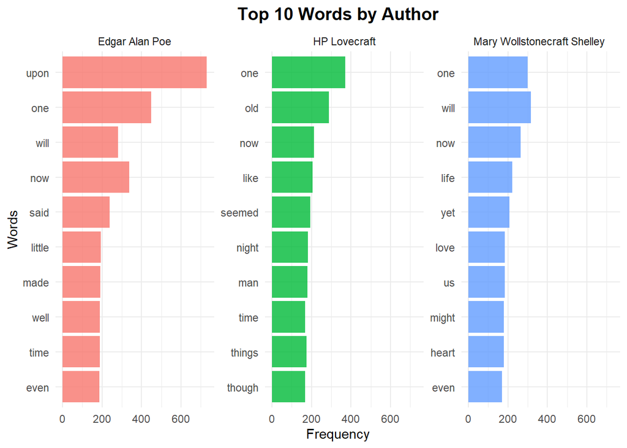

```r
top_words_per_author <- word_freq %>%
  group_by(author) %>%
  slice_head(n = 10) %>%
  ungroup()

ggplot(top_words_per_author, aes(x = reorder(splitted, freq), y = freq, fill = author)) +
  geom_col(alpha = 0.8) +
  coord_flip() +
  facet_wrap(~author, scales = "free_y") +
  labs(title = "Top 10 Words by Author",
       x = "Words", y = "Frequency") +
  theme_minimal() +
  theme(plot.title = element_text(hjust = 0.5, size = 14, face = "bold"),
        legend.position = "none")
```

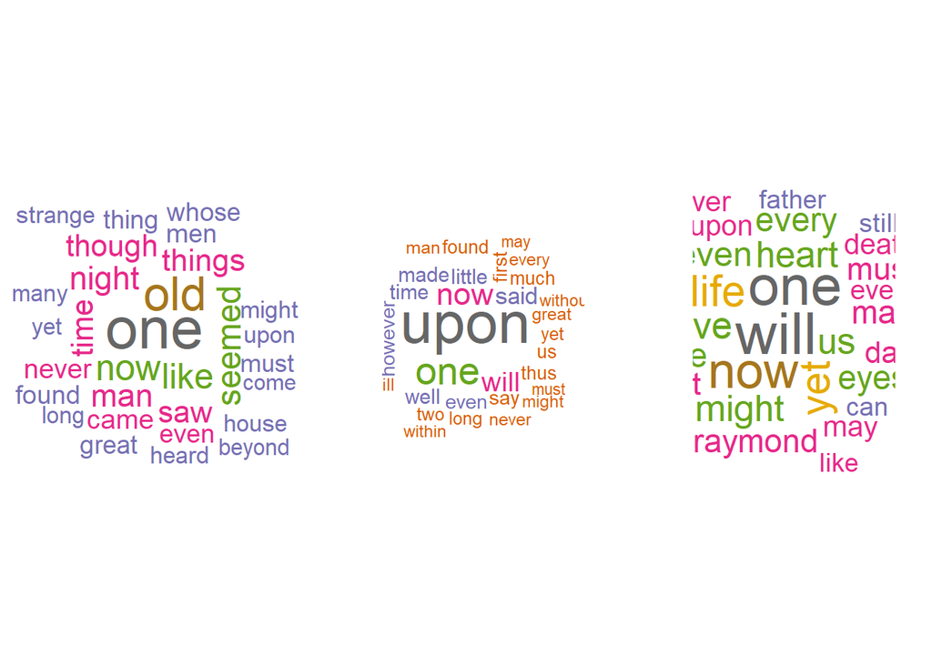

```r
if (require(wordcloud, quietly = TRUE) && require(RColorBrewer, quietly = TRUE)) {
  par(mfrow = c(1, 3))
  for (author_name in authors) {
    author_words <- word_freq %>%
      filter(author == author_name) %>%
      head(30)

    wordcloud(words = author_words$splitted,
              freq = author_words$freq,
              max.words = 30,
              random.order = FALSE,
              colors = brewer.pal(8, "Dark2"),
              main = paste("Word Cloud:", author_name))
  }
  par(mfrow = c(1, 1))
} else {
  cat("Word clouds skipped - wordcloud or RColorBrewer not available\n")
}
```

## Classifier implementation

```r
naiveBayes <- setRefClass("naiveBayes",
       fields = list(
         class_priors = "table",
         #Word probabilities -> probabilities of words given class.
         #Structure:
         #HP Lovecraft
         #hello   free  money    now
        #  0.25   0.25   0.40   0.10
         word_probabilities = "list",

        #A vector of all words available in the training data
         vocabulary = "character",

        #A number of all words in training data used to find P(feature)
        total_words_in_X = "numeric",

        computed_score = "data.frame"

       ),
       methods = list(
                    # prepare your training data as X - bag of words for each of your
                    # messages and corresponding label for the message encoded as 0 or 1
                    # (binary classification task)
                    fit = function(X, y)
                    {
                      X <- X[order(X$id...1), ]
                      y <- y[order(y$id), ]

                      stopifnot(all(X$id...1 == y$id))

                      vocabulary <<- setdiff(colnames(X), "id...1")
                      class_counts <- table(y$author)
                      total_words_in_X <<- sum(colSums(X[, 2:ncol(X)]))


                      class_priors <<- class_counts / sum(class_counts)
                      word_probabilities <<- list()
                        for (class in names(class_counts)) {
                          # subset X where y == class
                          X_class <- X[y$author == class, , drop = FALSE]
                          # sum counts of each word in that class
                          word_counts <- colSums(X_class[, 2:ncol(X_class)])

                          # add +1 to each count to avoid multiplying by 0
                          word_counts <- word_counts + 1
                          total_count <- sum(word_counts)


                          probs <- word_counts / total_count

                          word_probabilities[[class]] <<- probs
                    }



                    },

                    # return prediction for a single message
                      predict = function(message) {
                        message_df <- data.frame(text = message, stringsAsFactors = FALSE)
                        tidy_message <- message_df %>%
                          unnest_tokens(splitted, text, token = "words") %>%
                          filter(!(splitted %in% splitted_stop_words)) %>%
                          filter((splitted %in% vocabulary))
                        probs_per_class <- c()

                        for (class in names(class_priors)) {
                          p_class <- class_priors[class]
                          p_observation_given_class <- 1

                          for (word in tidy_message$splitted) {
                            p_w_given_class <- word_probabilities[[class]][word]
                            p_observation_given_class <- p_observation_given_class * p_w_given_class
                          }

                          probs_per_class[class] <- (p_class * (p_observation_given_class))
                        }

                        predicted_class <- names(which.max(probs_per_class))
                        return(predicted_class)

                    }
                  ,


                      score = function(X_test, y_test)
                      {
                            confusion <- matrix(0, nrow = 3, ncol = 3)
                            rownames(confusion) <- c("Edgar Alan Poe", "HP Lovecraft", "Mary Wollstonecraft Shelley ")
                            colnames(confusion) <- c("Edgar Alan Poe", "HP Lovecraft", "Mary Wollstonecraft Shelley ")
                            failures <- vector("list", length(X_test))
                            count <- 0
                            for (i in seq_along(X_test)) {
                                pred <- predict(X_test[i])
                                true <- y_test[i]
                                confusion[true, pred] <- confusion[true, pred] + 1
                                if (pred != true) {
                                    count <- count + 1
                                    failures[[count]] <- X_test[i]
                                }
                            }

                            confusion

                            scores <- data.frame(
                              Class=rownames(confusion),
                              TP=0, FP=0, FN=0,
                              Precision=0, Recall=0, F1=0)
                            total <- sum(confusion)

                            for (i in 1:3) {
                              tp <- confusion[i, i]
                              fp <- sum(confusion[-i, i])
                              fn <- sum(confusion[i, -i])
                              precision <- tp / (tp + fp)
                              recall <- tp / (tp + fn)
                              f1 <- (2*precision*recall /(precision+recall))
                              scores[i, 2:ncol(scores)] <- c(tp, fp, fn, precision, recall, f1)
                            }
                            computed_score <<- scores
                            return(list(score = scores,  failures = failures))
                      }
                  )
       )
model = naiveBayes()
model$fit(X=bow, y=author_labels)
result <- model$score(X_test=X_test, y_test=y_test)
```

## Score of a model (in metrics):

```r
model$computed_score
```

```
##                          Class   TP  FP  FN Precision    Recall        F1
## 1               Edgar Alan Poe 1951 343 423 0.8504795 0.8218197 0.8359040
## 2                 HP Lovecraft 1354 227 307 0.8564200 0.8151716 0.8352869
## 3 Mary Wollstonecraft Shelley  1594 405 245 0.7973987 0.8667754 0.8306410
```

### Here are a few sentences that failed to classify correctly:

```r
for (i in 1:10) {
  print(result$failures[[i]])
}
```

[output not shown]

## Measure effectiveness of your classifier

- Note that accuracy is not always a good metric for your classifier. Look at precision and recall curves, F1 score metric.

  When evaluating the model, it’s important to understand the different types of classification results:
  - A *true positive* result is one where the model correctly predicts the positive class.
  - A *true negative* result is one where the model correctly predicts the negative class.
  - A *false positive* result is one where the model incorrectly predicts the positive class when it is actually negative.
  - A *false negative* result is one where the model incorrectly predicts the negative class when it is actually positive.

  Precision measures the proportion of true positive predictions among all positive predictions made by the model.

  $$Precision = \frac{TP}{TP+FP}$$

  Recall, on the other hand, measures the proportion of true positives identified out of all actual positive cases.

  $$Recall = \frac{TP}{TP+FN}$$

  F1 score is the harmonic mean of both precision and recall.

  $$F1 = \frac{2\times Precision \times Recall}{Precision + Recall}$$

  **See [this link](https://cohere.com/blog/classification-eval-metrics) to find more information about metrics.**
- Visualize them.
- Show failure cases.

Summarize your work by explaining in a few sentences the points listed below.

- Describe the method implemented in general. Show what are mathematical foundations you are basing your solution on.
- List pros and cons of the method. This should include the limitations of your method, all the assumption you make about the nature of your data etc.
- Explain why accuracy is not a good choice for the base metrics for classification tasks. Why F1 score is always preferable?